# Emisiones de CO2

Ventura Giménez & Ivan Navarro

19/12/2019

# Inicio del proyecto

## Emisones de CO2

El cambio climático que estamos padeciendo actualmente nos ha motivado para realizar un proyecto sobre este tema, ya que es un tema de rigurosa actualidad y que pone en contexto el escenario actual en lo referente a contaminación y emisiones de CO2. En concreto, en este proyecto nos hemos centrado en las emisiones de CO2 que realizan los paises a la atmósfera a nivel global.

Debido a que es una asignatura de R y no un informe para institución, decidimos dejar la mayoria a la vista.

## Packages:

El listado de paquetes que hemos utilizado para este proyecto es el siguiente:

```r
library(tidyverse)
library(rio)
library(ggplot2)
library(dplyr)
library(ggThemeAssist)
library(tidyquant)
library(dygraphs)
library(rworldmap)
library(maps)
library(ggmap)
library(viridis)
library(hrbrthemes)
```

## Importación de datos:

A continuación importamos los *dataframes* que hemos obtenido mayoritariamente de la página **https://cdiac.ess-dive.lbl.gov/trends/emis/meth_reg.html**. Concretamente, los *dataframes* a nivel nacional y global hasta el año 2014.(df y df2). El resto de *dataframes* los hemos obtenido del estudio realizado por **https://ourworldindata.org/**, sobre el cambio climático y las emisiones.(df4,df5,df6).

En general, hemos tratado los datos, pero debido al poco tiempo no hemos podido perfeccionar el trabajo tanto como quisieramos.

```r
df <- rio::import("./datos/global.1751_2014v2.csv")
df2 <- rio::import("./datos/nation.1751_2014v2.csv")
df4 <- rio::import("./datos/co_emissions_per_capita.csv")
df5 <- rio::import("./datos/greenhouse-gas-emissions-by-sector.csv")
df6 <- rio::import("./datos/annual-co-emissions-by-region.csv")
```

### df

En primer dataframe nos encontramos los datos de emisiones a nivel global. Debido al nombre nada manejable de las columnas, decidimos cambiarla. Con este df intentaremos obtener la evolución de las emisiones de CO2 a nivel global, concretamente, las emisiones referidas al consumo de combustibles fósiles.

### df2

En este dataframe nos encontramos los datos de emisiones a nivel estatal. Tambien cambiamos los nombres, asi como, relaizamos una copia para tener constancia de los datos y unidades de medida.

### df4,df5,df6

Estos datos nos otorgan de forma directa lo que buscamos

## Emisiones De CO2 a nivel global acumulados(incluyendo China, Iddia y EEUU)

Con estos datos queremos obtener una visión global de la contaminacion por regiones, también incluimos a **China, India y Estados Unidos** debido a su importancia en el cómputo global. Lo obendremos de forma acumulada para obtener el nivel global de contaminación.

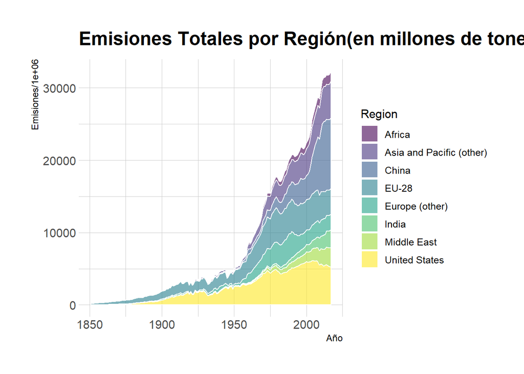

```r
list_of_values2 <- c("EU-28","Europe (other)","United States","Africa","Middle East","India","China","Asia and Pacific (other)")

Global <- filter(df6,`Entity` %in% list_of_values2) %>% filter(`Year`>1850)

Global <- select(Global,1,3:4)

names(Global) <- c("Region","Año","Emisiones")

ggplot(Global,aes(x = Año, y = Emisiones/1000000,fill=Region))  +geom_line(color="dark") + theme_minimal()+ geom_area(alpha=0.6 , size=.5, colour="white") +scale_fill_viridis(discrete = T) + theme_ipsum() + ggtitle("Emisiones Totales por Región(en millones de toneladas")
```

A continuación evaluamos la evolucion de los principales países europeos, para ver se de un tiempo a esta parte se ha logrado reducir los niveles de CO2 producidos por éstos.

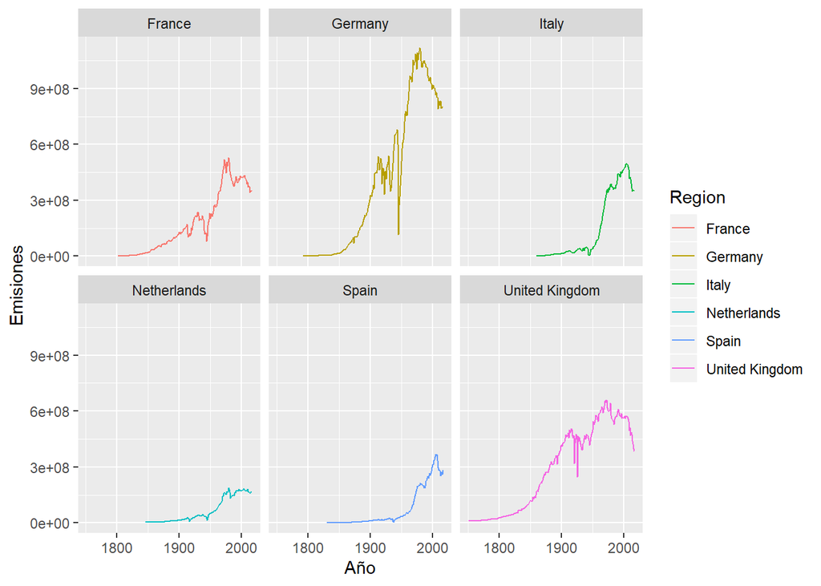

```r
list_of_values3 <- c("Germany","Spain","Italy","United Kingdom","France","Netherlands")
Paises <- filter(df6,`Entity` %in% list_of_values3)

Paises <- select(Paises,1,3:4)

names(Paises) <- c("Region","Año","Emisiones")

ggplot(Paises) + geom_line(aes(Año, Emisiones, color = Region)) + facet_wrap(vars(Region), nrow = 2, ncol = 3 )
```

### Emisiones en España

En lo que se refiere a España, vamos a estudiar el nivel de emisiones por parte del consumo de combustibles fosiles. En concreto, de combustibles líquidos, solidos y gaseosos, así como de las emisiones de la producción de cemento. En un principio íbamos a suprimir esta misma, pero su nivel es suficientemente alto como para mantenerla.

Los datos que obtenemos son en miles de toneladas.

En general, observamos una tendencia positiva a partir de 2007. Esto puede deberse a la destrucción de actividad productiva durante la crisis, y al racionamiento del consumo de este tipo de combustibles.

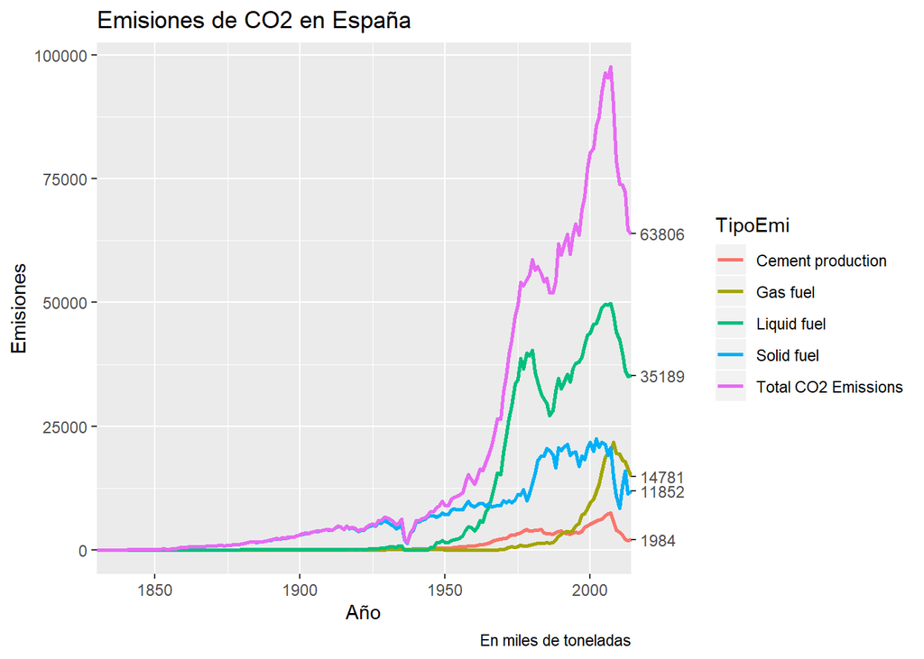

```r
espana <- df3 %>% filter(Nation == "SPAIN")

espana <- select(espana,-c(`Gas flaring`,`Bunker fuels`,`Per Capita CO2`))

espana <- select(espana,-c(Nation))

#Hay que hacer los datos Tidy

espana <- gather(espana,TipoEmi,CantCO2,2:6)

#hacemos el gráfico

Emis_ends <- espana %>% group_by(`TipoEmi`) %>% top_n(1, Year) %>% pull(`CantCO2`)

espana %>% ggplot(aes(x = Year, y = CantCO2, color=TipoEmi)) + geom_line(size=1)  +
labs(title = "Emisiones de CO2 en España" ,  caption = "En miles de toneladas" , x = "Año" , y = "Emisiones") + scale_y_continuous(sec.axis = sec_axis(~ ., breaks = Emis_ends)) +   #- sec_axis() especifica un eje secundario
     scale_x_continuous(expand = c(0, 0))
```

## Emisiones de CO2 por sectores en España (1990-2010)

Si analizamos los sectores productivos de nuestro país encontramos que el sector energético y transporte son los más contaminantes.

```r
los6<- df5 %>% filter (Entity == "Spain") %>% filter(Year>1989) %>% filter(Year<2011) %>% select(-c(1:2,10:11))
names(los6) <- c("Año","Otros","Basura","Industria","Hogares y Comercios","Transporte","Agricultura","Energia")

dygraph(los6,main = "Emisiones CO2 x SECTORES") %>% dyOptions(stackedGraph = TRUE) %>%
  dyRangeSelector() %>% dyLegend(width = 400, show="follow")
```

[interactive chart not shown]

### Emisiones de CO2 a nivel global

En este punto intentamos observar el nivel en **2014** de las emisiones sobre el consumo y la producción de cemento. Así como ver cual de todos es mayor a nivel absoluto.

El resultado obtenido es el esperado, siendo mayor el de combustibles fosiles solidos a los líquidos o gasesosos. En cambio, la quema de gas es prácticamente residual en nuesto estudio.

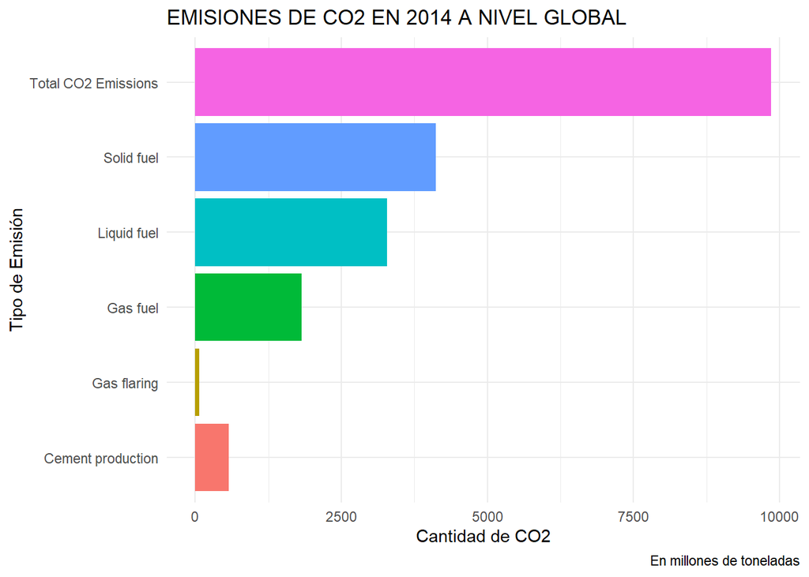

```r
#Grafico de emisiones totales a nivel mundial, por tipo


CO2mundial <- df %>% filter(Year == 2014)

CO2mundial <- select(CO2mundial,-c(8))

#Cambiamos el formato de la tabla.

CO2mundial <- gather(CO2mundial,TipoEmi,CantCo2,2:7)

ggplot(CO2mundial,aes(TipoEmi,CantCo2, fill=TipoEmi)) + geom_bar(stat = "identity") + coord_flip() + theme_minimal() + theme(legend.position="none") + labs(title = "EMISIONES DE CO2 EN 2014 A NIVEL GLOBAL" ,  caption = "En millones de toneladas" , x = "Tipo de Emisión" , y = "Cantidad de CO2")
```

### Países con mayores emisiones a nivel absoluto.

En este punto, queremos obtener cual de los países contamina en mayor medida a nivel **absoluto**. Para ello utilizamos un filtrado en el ultimo dato de que disponemos(2014) y ordenamos para obtener los *10 países* con mayores emisiones globales. También añadimos a Espana para saber en que nivel estamos con los mayores contaminadores por medio del *consumo de combustibles fosiles*. En el caso de España nos encontramos en la posición 25 de este ranking.

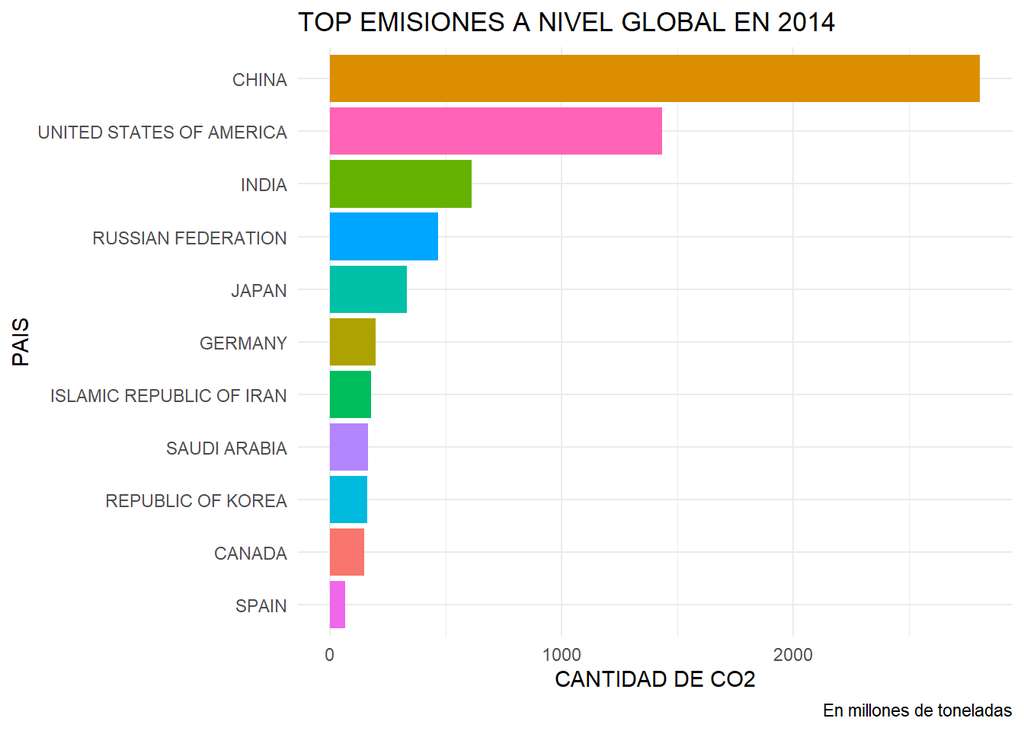

```r
mundialtop <- df3 %>% filter(Year==2014)

mundialtop <- select(mundialtop, 1,3)

mundialtop <- mundialtop %>% arrange(desc(`Total CO2 Emissions`))

mundialtop <- mundialtop[c(1:10,25),]

mundialtop <- gather(mundialtop,Emision_total, CantidadCO2, 2)

ggplot(mundialtop,aes(reorder(Nation,CantidadCO2), CantidadCO2/1000,fill=Nation)) + geom_bar(stat = "identity") + theme_minimal() + theme(legend.position="none")+coord_flip() + labs(title = "TOP EMISIONES A NIVEL GLOBAL EN 2014" ,  caption = "En millones de toneladas" , x = "PAIS" , y = "CANTIDAD DE CO2")
```

```r
mundialevol <- df3

mundialevol <- select(mundialevol,1:3)

list_of_values2 <- c("CHINA","UNITED STATES OF AMERICA","INDIA","RUSSIAN FEDERATION","JAPAN","GERMANY","SPAIN","USSR")
mundialevol <- filter(mundialevol,`Nation` %in% list_of_values2)
mundialevol <- mundialevol %>% filter(`Year`> 1900) %>% group_by(Nation)

mundialevol <- spread(mundialevol,`Nation`,`Total CO2 Emissions`)

dygraph(mundialevol,main = "Emisiones totales del Top") %>%
  dyOptions(labelsUTC = TRUE, fillGraph=TRUE, fillAlpha=0.1, drawGrid = FALSE)%>%
  dyRangeSelector() %>%
  dyCrosshair(direction = "vertical") %>%
  dyHighlight(highlightCircleSize = 5, highlightSeriesBackgroundAlpha = 3, hideOnMouseOut = FALSE)  %>%
  dyRoller(rollPeriod = 1) %>% dyLegend(width = 500,show = "follow")
```

[interactive chart not shown]

### Emisiones de CO2 Per Cápita. Clasificación mundial.

Una vez realizado el examen en términos absolutos, procedemos a cambiar para mostrar una visión en términos relativos. Para ello nos ayudamos de la clasificación de emisiones per cápita. En este punto,los principales países que obtenemos en esta clasificación son paises productores de petróleo. Suponemos que esto es debido a la baja población de éstos. LOs datos mostrados son del año *2014*.

Para realizar la representación hemos tenido que cambiar el tipo de campo, ya que así no se podían ordenar correctamente. En concreto, hemos cambiado de *character* a *numeric*. Por otro lado , hemos transformado la tabla en formato **gather** para hacer la representación gráfica.

```r
mundialpc <- df3 %>% filter(Year==2014)

mundialpc$"Per Capita CO2" <- as.numeric(as.character(mundialpc$"Per Capita CO2"))
sapply(mundialpc, mode)
```

```
##              Nation                Year Total CO2 Emissions          Solid fuel
##         "character"           "numeric"           "numeric"           "numeric"
##         Liquid fuel            Gas fuel   Cement production         Gas flaring
##           "numeric"           "numeric"           "numeric"         "character"
##      Per Capita CO2        Bunker fuels
##           "numeric"           "numeric"
```

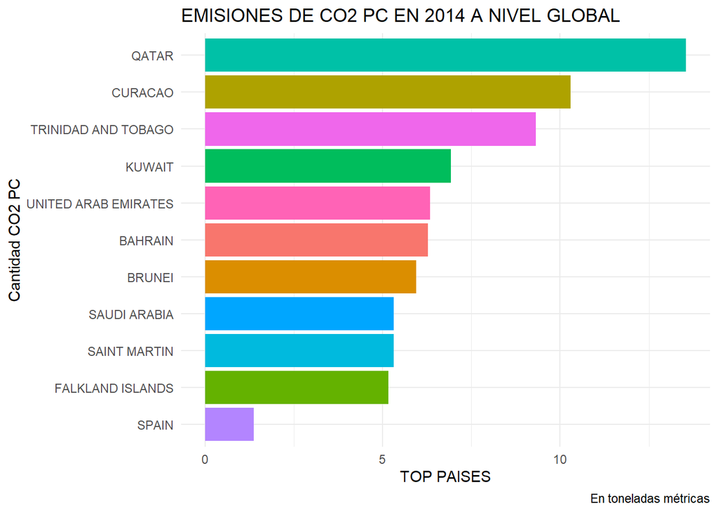

```r
mundialpc <- mundialpc %>% arrange(desc(`Per Capita CO2`))

mundialpc <- mundialpc[c(1:10,77),]
mundialpc <- select(mundialpc, 1,2,9)

#transformamos los datos en tidy

mundialpc <- gather(mundialpc,EmisionPC,CantidadPC,3)

mundialpc <- select(mundialpc,1,3,4)

ggplot(mundialpc,aes(reorder(Nation,CantidadPC), CantidadPC,fill=Nation)) + geom_bar(stat = "identity") + theme_minimal() + theme(legend.position="none")+coord_flip() + labs(title = "EMISIONES DE CO2 PC EN 2014 A NIVEL GLOBAL" ,  caption = "En toneladas métricas" , x = "Cantidad CO2 PC" , y = "TOP PAISES")
```

###Emisiones mundiales de CO2.

Una vez realizado lo anterior, queremos representar como la visualización del mapa mundial en términos per cápita. En este punto, la representación no quedaba del todo correcta debido a un valor anómalo como es Qatar que distorsionaba todo el mapa y no resultaba apreciable el cambio en otros países más importantes en nuestro estudio.

```r
#Emisiones mundiales PC 2014


World2 <- df4 %>% filter(Year==2014)
World2 <-select(World2,1,2,4)
World2 <- World2[-c(140),] #eliminamos Qatar, valor anómalo.
names(World2) <- c("Entity","Code","Emisiones Per Capita CO2")

spdf <- joinCountryData2Map(World2, joinCode="NAME", nameJoinColumn="Entity")
```

```
## 192 codes from your data successfully matched countries in the map
## 4 codes from your data failed to match with a country code in the map
## 51 codes from the map weren't represented in your data
```

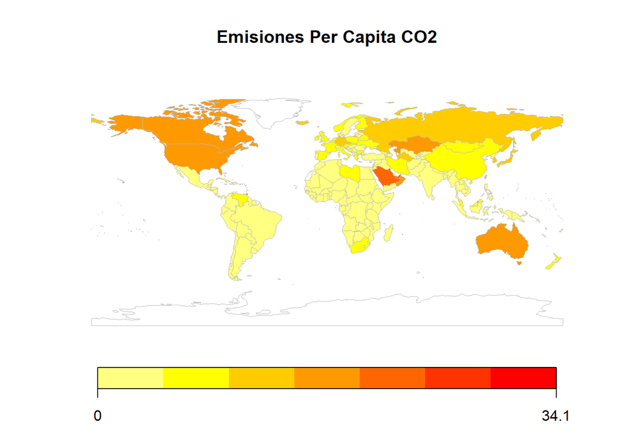

```r
mapCountryData(spdf, nameColumnToPlot="Emisiones Per Capita CO2", catMethod="fixedWidth")
```

A su vez, hacemos el mismo análisis, con el total de emisiones producidas por los países a nivel global. Para ello utilizamos el mismo código cambiando el data frame.

```r
#Emisiones Totales mapa mundial(absoluto)

Map <- df2 %>% filter(Year == 2014)

Map <- select(Map,1,3)

names(Map) <- c("Pais","Emisiones Totales")

spdf <- joinCountryData2Map(Map, joinCode="NAME", nameJoinColumn="Pais")
```

```
## 204 codes from your data successfully matched countries in the map
## 16 codes from your data failed to match with a country code in the map
## 39 codes from the map weren't represented in your data
```

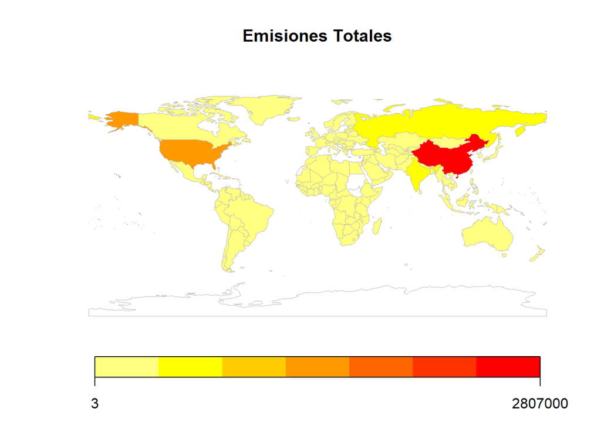

```r
mapCountryData(spdf, nameColumnToPlot="Emisiones Totales", catMethod="fixedWidth")
```

# Conclusión.

Como conclusión, habiendo analizado los datos que hemos podido obtener mediante el tratamiento de los datos obtenidos de diferentes fuentes, uno de los mayores problemas a los que se enfrenta nuestra sociedad es la reducción de las emisiones de CO2. La evolución que observamos, continuarán aumnetando este tipo de emisiones por falta de consenso politico, ya que los países más contaminantes no tienen la voluntad necesaria para adoptar mediadas para reducir las emisiones ya que estos países deberían de cambiar sus modelos energéticos y productivos y avanzar hacia una mayor sostenibilidad ambiental.

Por lo que respecta a nuestro país, nuestras emisiones son muy reducidas comparadas con el resto de potencias en términos abolustos, no así en terminos relativos. Por lo que nuestras medidas, a nivel global de reducciónes de CO2 no ayudan demasiado al estancamiento del cambio climático.

En definitiva, nos ha parecido un tema interesante debido a la actualidad y para hacernos una idea del nivel de contaminación global en la actualidad.